# Constraints on universality classes of SPT-trivial phase transitions in 1d

Here I collect a couple results that rule out certain universality classes of phase transitions between symmetry-protected topological (SPT) phases and trivial phases in spin chains. I hope to answer the following question:

> In spin chains, are there any SPT-trivial phase boundaries that are described by conformal field theories that are unitary minimal models with a central charge $c<1$?

To be explicit, I would like to exclude tricritical points or other fine-tunings. As we’ll see below, the answer is in fact no.

### Motivation

My motivation for this question comes mostly from noticing a small pattern in a couple $\mathbb{Z}_2 \times \mathbb{Z}_2$ protected phases – a) the Haldane phase connected to the AKLT model and b) perturbed cluster states on a chain. I noticed that the trivial-SPT phase transition was seemingly always $c=1$, and whenever there were transitions with smaller central charge in the phase diagram, they were necessarily involving a symmetry-broken phase. The $\mathbb{Z}_2 \times \mathbb{Z}_2$-symmetric Ashkin-Teller model also has $c=1$, so it seemed to me that $c=1$ was likely a symptom of the $\mathbb{Z}_2 \times \mathbb{Z}_2$ symmetry. It was then tempting that SPT-trivial transitions for SPTs protected by $\mathbb{Z}_2 \times \mathbb{Z}_2$ might generically have $c=1$ – I wasn’t sure how the symmetry was constraining the central charge, and whether this might generalize for SPTs protected by different symmetry groups, like $\mathbb{Z}_3 \times \mathbb{Z}_3$. Below I give examples of a couple papers showing the $c=1$ transitions in these $\mathbb{Z}_2 \times \mathbb{Z}_2$-symmetric models.

The Haldane phase is a phase of gapped spin-$1$ antiferromagnets protected by $\mathbb{Z}_2 \times \mathbb{Z}_2$ (among other symmetries). On the addition of an anisotropy (local $(S^z)^2$), the Haldane phase suffers a phase transition into a trivial phase without topological order and without symmetry breaking. An example phase diagram is given in this paper by [Ejima, Lange, and Fehske](https://arxiv.org/abs/2104.06649) for the spin-$1$ chain $H = \sum_{i} J\left( S^x_i S^x_{i+1}+S^y_i S^y_{i+1}+\Delta S^z_i S^z_{i+1}\right) + D (S^z_i)^2$:

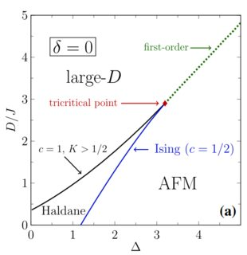

Note that the phase transition between the Haldane phase and the large-D phase is described by a conformal field theory with $c=1$. There is a $c=1/2$ phase transition out of the Haldane phase into a different antiferromagnetic phase, but the latter phase has $\mathbb{Z}_2$ symmetry-breaking, so it’s not an example of a topological to trivial phase transition.

Similarly, taking linear combinations of the $\mathbb{Z}_2 \times \mathbb{Z}_2$-protected cluster state Hamiltonian $H_{\text{SPT}} = -\sum_{i} \sigma^z_{i-1} \sigma^x_i \sigma^z_{i+1}$ with a trivial paramagnet $H_{0} =-\sum_i \sigma^x_i$ and Ising $H_{\text{Ising}} =-\sum_i (-1)^i \sigma^z_i \sigma^z_{i+1}$ gives rise to the following phase diagram

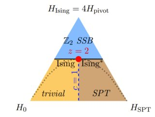

featuring a $c=1$ direct transition between the trivial and SPT phases. Again, there’s lines of $c=1/2$ phase transitions, but those are not between the trivial and SPT phases. This figure came from a paper by [Tantivasadakarn, Thorngren, Vishwanath, and Verresen](https://arxiv.org/abs/2110.07599) which investigated a few other phase diagrams coming from interpolating between SPT, trivial, and pivot Hamiltonians, the last of which generates a unitary transformation between the SPT and trivial fixed points.

(As an aside, one usually discusses the $\mathbb{Z}_2 \times \mathbb{Z}_2$ symmetry of the cluster state generated by $\sigma^x$ on the even and odd sublattices. That symmetry holds if we keep to the bottom-most horizontal line of the phase diagram. We only preserve the product of $\sigma^x$ on all sites on adding the Ising Hamiltonian, and then the SPT is protected by a combination of that symmetry and a version of time-reversal symmetry.)

### An argument for $c\geq 1$

The answer to the question posed at top is that CFT-described direct transitions between bosonic SPT phases in $(1+1)d$ indeed suffer $c \geq 1$. This result is motivated and explained in a paper by [Tsui, Huang, Jiang, and Lee](https://arxiv.org/pdf/1701.00834.pdf). Note that this result is more general than my question – I was concerned with SPT-trivial transitions, and their result also appears to hold for transitions from nontrivial SPT phase to different nontrivial SPT phases protected by the same symmetry.

Here is how I interpret the main argument in section 10 of the above paper. Any conformal field theory at the transition must be invariant under the shared symmetries of the two abutting phases. However, unitary minimal models can only have either global on-site $\mathbb{Z}_2$ or $S_3$ symmetry. The symmetry groups protecting SPTs in spin chains are necessarily different than just $\mathbb{Z}_2$ or $S_3$, so the CFTs at the transition can’t be unitary minimal models.

The claim that unitary minimal models have relatively restricted global on-site symmetries ($\mathbb{Z}_2$ or $S_3$) is argued in a paper by [Ruelle and Verhoeven](https://arxiv.org/abs/hep-th/9803129).

### Thoughts on the argument

I’m not sure that I fully understand the argument. Does this mean that the mere presence of extra discrete global on-site symmetries in a lattice model is enough to rule out a transition being described by a unitary minimal model? This interpretation of the above argument would be quite surprising to me. In a model with $\mathbb{Z}_2 \times G$ symmetry, where $G$ could be for instance some gigantic group, I feel that a phase transition that broke just this $\mathbb{Z}_2$ subgroup would stay in the Ising universality class despite the presence of the unbroken $G$.

It’s tempting that one could indeed construct such a counterexample by adding trivial degrees of freedom on each site of the Ising model to enhance the symmetry group from $\mathbb{Z}_2$ to $\mathbb{Z}_2 \times G$. On the other hand, maybe such a trivial counterexample would be explicitly ruled out with reasonable hypotheses (for example, such a model with only Ising-type interactions between the original degrees of freedom would be rather fine-tuned, given that there could be many local symmetry-consistent interactions once the additional degrees of freedom were added).